# Kaggle competition - Energy prediction

09/12/2022

## Modèle 1 : Regression linéaire multiple.

**1.** On import les dataset train et test.

```r
library(caret)
train <- read.csv("~/Machine learning/Competition/train.csv")
test <- read.csv("~/Machine learning/Competition/test.csv")
```

**2.** On visualise les data puis on les clean.

```r
View(train)
View(test)

train$Day_of_week <- match(train$Day_of_week, c("Monday", "Tuesday", "Wednesday", "Thursday", "Friday", "Saturday", "Sunday"))

test$Day_of_week <- match(test$Day_of_week, c("Monday", "Tuesday", "Wednesday", "Thursday", "Friday", "Saturday", "Sunday"))

#Ici seul la variable Day_of_week n'est pas numérique, on choisi d'attribuer à chaque jour une valeur.
```

**3.** On split les data en training data et testing data.

```r
set.seed(123)
splitIndex <- createDataPartition(train$Appliances, p = 0.75, list = FALSE)
train_data <- train[splitIndex, ]
test_data <- train[-splitIndex, ]

dim(train_data) #On regarde les dimensions des nouveaux datasets.
```

```
## [1] 11102    29
```

```r
dim(test_data)
```

```
## [1] 3699   29
```

**4.** On crée le modèle linéaire en utilisant la fonction lm.

```r
model <- lm(Appliances~., data = train_data)
model
```

```
##
## Call:
## lm(formula = Appliances ~ ., data = train_data)
##
## Coefficients:
## (Intercept)       lights           T1         RH_1           T2         RH_2
##    65.88487      1.97631      0.81345     15.61799    -16.48595    -12.73022
##          T3         RH_3           T4         RH_4           T5         RH_5
##    24.63966      4.86517     -1.82476     -0.32613     -3.67765      0.13906
##          T6         RH_6           T7         RH_7           T8         RH_8
##     6.68415      0.30573      2.03725     -1.79667      6.89282     -4.39044
##          T9         RH_9        T_out  Press_mm_hg       RH_out    Windspeed
##   -13.83759     -1.47980     -9.44522      0.04967     -1.01177      1.83188
##  Visibility    Tdewpoint          rv1          rv2  Day_of_week
##     0.15619      4.25945     -0.02067           NA      2.22517
```

```r
summary(model)
```

```
##
## Call:
## lm(formula = Appliances ~ ., data = train_data)
##
## Residuals:
##     Min      1Q  Median      3Q     Max
## -257.53  -43.04  -19.20    6.43  805.06
##
## Coefficients: (1 not defined because of singularities)
##              Estimate Std. Error t value Pr(>|t|)
## (Intercept)  65.88487  125.48739   0.525 0.599572
## lights        1.97631    0.12571  15.721  < 2e-16 ***
## T1            0.81345    2.45128   0.332 0.740010
## RH_1         15.61799    0.90222  17.311  < 2e-16 ***
## T2          -16.48595    2.15806  -7.639 2.36e-14 ***
## RH_2        -12.73022    1.01899 -12.493  < 2e-16 ***
## T3           24.63966    1.39139  17.709  < 2e-16 ***
## RH_3          4.86517    0.89929   5.410 6.43e-08 ***
## T4           -1.82476    1.37162  -1.330 0.183425
## RH_4         -0.32613    0.84785  -0.385 0.700497
## T5           -3.67765    1.55396  -2.367 0.017968 *
## RH_5          0.13906    0.11520   1.207 0.227389
## T6            6.68415    0.84138   7.944 2.14e-15 ***
## RH_6          0.30573    0.08949   3.416 0.000637 ***
## T7            2.03725    1.74369   1.168 0.242689
## RH_7         -1.79667    0.56371  -3.187 0.001440 **
## T8            6.89282    1.29413   5.326 1.02e-07 ***
## RH_8         -4.39044    0.48863  -8.985  < 2e-16 ***
## T9          -13.83759    2.33581  -5.924 3.23e-09 ***
## RH_9         -1.47980    0.53851  -2.748 0.006007 **
## T_out        -9.44522    2.01722  -4.682 2.87e-06 ***
## Press_mm_hg   0.04967    0.14155   0.351 0.725649
## RH_out       -1.01177    0.41616  -2.431 0.015066 *
## Windspeed     1.83188    0.45920   3.989 6.67e-05 ***
## Visibility    0.15619    0.07603   2.054 0.039965 *
## Tdewpoint     4.25945    1.95502   2.179 0.029374 *
## rv1          -0.02067    0.06089  -0.340 0.734232
## rv2                NA         NA      NA       NA
## Day_of_week   2.22517    0.46830   4.752 2.04e-06 ***
## ---
## Signif. codes:  0 '***' 0.001 '**' 0.01 '*' 0.05 '.' 0.1 ' ' 1
##
## Residual standard error: 92.84 on 11074 degrees of freedom
## Multiple R-squared:  0.1718, Adjusted R-squared:  0.1697
## F-statistic: 85.06 on 27 and 11074 DF,  p-value: < 2.2e-16
```

**5.** On calcule la MSE avec le test_data.

```r
prediction1 = predict(model,newdata = test_data)
mse = mean((test_data$Appliances-prediction1)^2)
mse
```

```
## [1] 9878.648
```

**6.** On essaye différents modèles avec lm.

```r
model2 <- lm(Appliances~.-lights, data = train_data)
model2
```

```
##
## Call:
## lm(formula = Appliances ~ . - lights, data = train_data)
##
## Coefficients:
## (Intercept)           T1         RH_1           T2         RH_2           T3
##    59.50555      1.80508     16.52088    -18.94440    -13.58466     24.57073
##        RH_3           T4         RH_4           T5         RH_5           T6
##     4.94458      4.37847      1.71945     -3.63929      0.22102      7.17156
##        RH_6           T7         RH_7           T8         RH_8           T9
##     0.36620      1.48960     -2.07227      9.09686     -5.60076    -20.31836
##        RH_9        T_out  Press_mm_hg       RH_out    Windspeed   Visibility
##    -2.03520     -9.86086      0.02480     -0.87691      2.25710      0.17914
##   Tdewpoint          rv1          rv2  Day_of_week
##     4.33792     -0.02407           NA      2.14878
```

```r
summary(model2)
```

```
##
## Call:
## lm(formula = Appliances ~ . - lights, data = train_data)
##
## Residuals:
##     Min      1Q  Median      3Q     Max
## -256.07  -43.61  -20.26    5.92  804.01
##
## Coefficients: (1 not defined because of singularities)
##              Estimate Std. Error t value Pr(>|t|)
## (Intercept)  59.50555  126.87367   0.469 0.639069
## T1            1.80508    2.47755   0.729 0.466278
## RH_1         16.52088    0.91034  18.148  < 2e-16 ***
## T2          -18.94440    2.17617  -8.705  < 2e-16 ***
## RH_2        -13.58466    1.02879 -13.205  < 2e-16 ***
## T3           24.57073    1.40676  17.466  < 2e-16 ***
## RH_3          4.94458    0.90922   5.438 5.49e-08 ***
## T4            4.37847    1.32816   3.297 0.000982 ***
## RH_4          1.71945    0.84707   2.030 0.042393 *
## T5           -3.63929    1.57113  -2.316 0.020557 *
## RH_5          0.22102    0.11635   1.900 0.057508 .
## T6            7.17156    0.85010   8.436  < 2e-16 ***
## RH_6          0.36620    0.09040   4.051 5.14e-05 ***
## T7            1.48960    1.76261   0.845 0.398067
## RH_7         -2.07227    0.56966  -3.638 0.000276 ***
## T8            9.09686    1.30073   6.994 2.83e-12 ***
## RH_8         -5.60076    0.48786 -11.480  < 2e-16 ***
## T9          -20.31836    2.32456  -8.741  < 2e-16 ***
## RH_9         -2.03520    0.54329  -3.746 0.000181 ***
## T_out        -9.86086    2.03934  -4.835 1.35e-06 ***
## Press_mm_hg   0.02480    0.14311   0.173 0.862448
## RH_out       -0.87691    0.42067  -2.085 0.037134 *
## Windspeed     2.25710    0.46347   4.870 1.13e-06 ***
## Visibility    0.17914    0.07685   2.331 0.019775 *
## Tdewpoint     4.33792    1.97663   2.195 0.028212 *
## rv1          -0.02407    0.06156  -0.391 0.695766
## rv2                NA         NA      NA       NA
## Day_of_week   2.14878    0.47345   4.539 5.72e-06 ***
## ---
## Signif. codes:  0 '***' 0.001 '**' 0.01 '*' 0.05 '.' 0.1 ' ' 1
##
## Residual standard error: 93.87 on 11075 degrees of freedom
## Multiple R-squared:  0.1533, Adjusted R-squared:  0.1513
## F-statistic: 77.11 on 26 and 11075 DF,  p-value: < 2.2e-16
```

```r
model3 <- lm(Appliances~.-lights-RH_1, data = train_data)
model3
```

```
##
## Call:
## lm(formula = Appliances ~ . - lights - RH_1, data = train_data)
##
## Coefficients:
## (Intercept)           T1           T2         RH_2           T3         RH_3
##   170.02936    -19.21770      4.19071     -0.12415     27.32521      9.14547
##          T4         RH_4           T5         RH_5           T6         RH_6
##     6.22440      3.30871     -4.60828      0.21024      6.95373      0.39561
##          T7         RH_7           T8         RH_8           T9         RH_9
##     3.34638     -3.10118      9.32926     -5.59493    -24.53450     -3.05358
##       T_out  Press_mm_hg       RH_out    Windspeed   Visibility    Tdewpoint
##   -12.19597     -0.14310     -1.64253      2.13347      0.20593      6.63587
##         rv1          rv2  Day_of_week
##    -0.01723           NA      2.74549
```

```r
summary(model3)
```

```
##
## Call:
## lm(formula = Appliances ~ . - lights - RH_1, data = train_data)
##
## Residuals:
##     Min      1Q  Median      3Q     Max
## -187.58  -44.93  -21.70    5.29  804.82
##
## Coefficients: (1 not defined because of singularities)
##              Estimate Std. Error t value Pr(>|t|)
## (Intercept) 170.02936  128.59214   1.322 0.186116
## T1          -19.21770    2.22228  -8.648  < 2e-16 ***
## T2            4.19071    1.78965   2.342 0.019217 *
## RH_2         -0.12415    0.72343  -0.172 0.863747
## T3           27.32521    1.41913  19.255  < 2e-16 ***
## RH_3          9.14547    0.89219  10.251  < 2e-16 ***
## T4            6.22440    1.34375   4.632 3.66e-06 ***
## RH_4          3.30871    0.85493   3.870 0.000109 ***
## T5           -4.60828    1.59333  -2.892 0.003833 **
## RH_5          0.21024    0.11806   1.781 0.074974 .
## T6            6.95373    0.86252   8.062 8.27e-16 ***
## RH_6          0.39561    0.09171   4.313 1.62e-05 ***
## T7            3.34638    1.78553   1.874 0.060933 .
## RH_7         -3.10118    0.57518  -5.392 7.12e-08 ***
## T8            9.32926    1.31981   7.069 1.66e-12 ***
## RH_8         -5.59493    0.49504 -11.302  < 2e-16 ***
## T9          -24.53450    2.34695 -10.454  < 2e-16 ***
## RH_9         -3.05358    0.54834  -5.569 2.62e-08 ***
## T_out       -12.19597    2.06522  -5.905 3.62e-09 ***
## Press_mm_hg  -0.14310    0.14491  -0.988 0.323412
## RH_out       -1.64253    0.42471  -3.867 0.000111 ***
## Windspeed     2.13347    0.47024   4.537 5.77e-06 ***
## Visibility    0.20593    0.07797   2.641 0.008276 **
## Tdewpoint     6.63587    2.00159   3.315 0.000918 ***
## rv1          -0.01723    0.06246  -0.276 0.782718
## rv2                NA         NA      NA       NA
## Day_of_week   2.74549    0.47925   5.729 1.04e-08 ***
## ---
## Signif. codes:  0 '***' 0.001 '**' 0.01 '*' 0.05 '.' 0.1 ' ' 1
##
## Residual standard error: 95.25 on 11076 degrees of freedom
## Multiple R-squared:  0.1281, Adjusted R-squared:  0.1261
## F-statistic: 65.09 on 25 and 11076 DF,  p-value: < 2.2e-16
```

```r
prediction2 = predict(model2,newdata = test_data)
mse = mean((test_data$Appliances-prediction2)^2)
mse
```

```
## [1] 10075.52
```

```r
prediction3 = predict(model3,newdata = test_data)
mse = mean((test_data$Appliances-prediction3)^2)
mse
```

```
## [1] 10400.31
```

```r
prediction2 = predict(model2,newdata = test)
to_be_submitted = data.frame(id=rownames(test), Appliances=prediction2)
write.csv(to_be_submitted , file = "to_be_submitted.csv", row.names = F)
#to_be_submitted
```

## Modèle 2 : Le modèle linéaire généralisé.

**1.** On import les dataset train et test.

```r
library(caret)

train <- read.csv("~/Machine learning/Competition/train.csv")
test <- read.csv("~/Machine learning/Competition/test.csv")
```

**2.** On visualise les data puis on les clean.

```r
View(train)
View(test)

train$Day_of_week <- match(train$Day_of_week, c("Monday", "Tuesday", "Wednesday", "Thursday", "Friday", "Saturday", "Sunday"))

test$Day_of_week <- match(test$Day_of_week, c("Monday", "Tuesday", "Wednesday", "Thursday", "Friday", "Saturday", "Sunday"))

#Ici seul la variable Day_of_week n'est pas numérique, on choisi d'attribuer à chaque jour une valeur.
```

**3.** On split les data en training data et testing data.

```r
set.seed(123)
splitIndex <- createDataPartition(train$Appliances, p = 0.75, list = FALSE)
train_data <- train[splitIndex, ]
test_data <- train[-splitIndex, ]

dim(train_data) #On regarde les dimensions des nouveaux datasets.
```

```
## [1] 11102    29
```

```r
dim(test_data)
```

```
## [1] 3699   29
```

**4.** On crée le modèle linéaire généralisé en utilisant la fonction glm.

```r
model4=glm(Appliances~.,data =train_data)

summary(model4)
```

```
##
## Call:
## glm(formula = Appliances ~ ., data = train_data)
##
## Deviance Residuals:
##     Min       1Q   Median       3Q      Max
## -257.53   -43.04   -19.20     6.43   805.06
##
## Coefficients: (1 not defined because of singularities)
##              Estimate Std. Error t value Pr(>|t|)
## (Intercept)  65.88487  125.48739   0.525 0.599572
## lights        1.97631    0.12571  15.721  < 2e-16 ***
## T1            0.81345    2.45128   0.332 0.740010
## RH_1         15.61799    0.90222  17.311  < 2e-16 ***
## T2          -16.48595    2.15806  -7.639 2.36e-14 ***
## RH_2        -12.73022    1.01899 -12.493  < 2e-16 ***
## T3           24.63966    1.39139  17.709  < 2e-16 ***
## RH_3          4.86517    0.89929   5.410 6.43e-08 ***
## T4           -1.82476    1.37162  -1.330 0.183425
## RH_4         -0.32613    0.84785  -0.385 0.700497
## T5           -3.67765    1.55396  -2.367 0.017968 *
## RH_5          0.13906    0.11520   1.207 0.227389
## T6            6.68415    0.84138   7.944 2.14e-15 ***
## RH_6          0.30573    0.08949   3.416 0.000637 ***
## T7            2.03725    1.74369   1.168 0.242689
## RH_7         -1.79667    0.56371  -3.187 0.001440 **
## T8            6.89282    1.29413   5.326 1.02e-07 ***
## RH_8         -4.39044    0.48863  -8.985  < 2e-16 ***
## T9          -13.83759    2.33581  -5.924 3.23e-09 ***
## RH_9         -1.47980    0.53851  -2.748 0.006007 **
## T_out        -9.44522    2.01722  -4.682 2.87e-06 ***
## Press_mm_hg   0.04967    0.14155   0.351 0.725649
## RH_out       -1.01177    0.41616  -2.431 0.015066 *
## Windspeed     1.83188    0.45920   3.989 6.67e-05 ***
## Visibility    0.15619    0.07603   2.054 0.039965 *
## Tdewpoint     4.25945    1.95502   2.179 0.029374 *
## rv1          -0.02067    0.06089  -0.340 0.734232
## rv2                NA         NA      NA       NA
## Day_of_week   2.22517    0.46830   4.752 2.04e-06 ***
## ---
## Signif. codes:  0 '***' 0.001 '**' 0.01 '*' 0.05 '.' 0.1 ' ' 1
##
## (Dispersion parameter for gaussian family taken to be 8619.394)
##
##     Null deviance: 115246569  on 11101  degrees of freedom
## Residual deviance:  95451167  on 11074  degrees of freedom
## AIC: 132140
##
## Number of Fisher Scoring iterations: 2
```

```r
coef(model4)
```

```
##  (Intercept)       lights           T1         RH_1           T2         RH_2
##  65.88487015   1.97631382   0.81345211  15.61798809 -16.48595419 -12.73022351
##           T3         RH_3           T4         RH_4           T5         RH_5
##  24.63965704   4.86516998  -1.82475946  -0.32613440  -3.67764848   0.13906443
##           T6         RH_6           T7         RH_7           T8         RH_8
##   6.68415052   0.30573318   2.03724537  -1.79666989   6.89282212  -4.39044276
##           T9         RH_9        T_out  Press_mm_hg       RH_out    Windspeed
## -13.83759204  -1.47979668  -9.44521966   0.04967486  -1.01176816   1.83188247
##   Visibility    Tdewpoint          rv1          rv2  Day_of_week
##   0.15618865   4.25944827  -0.02067144           NA   2.22517439
```

**5.** On teste différents modèles et on les testes pour choisir le meilleur.

```r
model4$aic #Plus le AIC est petit plus le modèle est performant.
```

```
## [1] 132139.8
```

```r
model5=glm(Appliances~.-lights,data =train_data)
model5$aic
```

```
## [1] 132382.9
```

```r
model6=glm(Appliances~lights+Press_mm_hg,data =train_data)
model6$aic
```

```
## [1] 133709.5
```

```r
summary(model5)
```

```
##
## Call:
## glm(formula = Appliances ~ . - lights, data = train_data)
##
## Deviance Residuals:
##     Min       1Q   Median       3Q      Max
## -256.07   -43.61   -20.26     5.92   804.01
##
## Coefficients: (1 not defined because of singularities)
##              Estimate Std. Error t value Pr(>|t|)
## (Intercept)  59.50555  126.87367   0.469 0.639069
## T1            1.80508    2.47755   0.729 0.466278
## RH_1         16.52088    0.91034  18.148  < 2e-16 ***
## T2          -18.94440    2.17617  -8.705  < 2e-16 ***
## RH_2        -13.58466    1.02879 -13.205  < 2e-16 ***
## T3           24.57073    1.40676  17.466  < 2e-16 ***
## RH_3          4.94458    0.90922   5.438 5.49e-08 ***
## T4            4.37847    1.32816   3.297 0.000982 ***
## RH_4          1.71945    0.84707   2.030 0.042393 *
## T5           -3.63929    1.57113  -2.316 0.020557 *
## RH_5          0.22102    0.11635   1.900 0.057508 .
## T6            7.17156    0.85010   8.436  < 2e-16 ***
## RH_6          0.36620    0.09040   4.051 5.14e-05 ***
## T7            1.48960    1.76261   0.845 0.398067
## RH_7         -2.07227    0.56966  -3.638 0.000276 ***
## T8            9.09686    1.30073   6.994 2.83e-12 ***
## RH_8         -5.60076    0.48786 -11.480  < 2e-16 ***
## T9          -20.31836    2.32456  -8.741  < 2e-16 ***
## RH_9         -2.03520    0.54329  -3.746 0.000181 ***
## T_out        -9.86086    2.03934  -4.835 1.35e-06 ***
## Press_mm_hg   0.02480    0.14311   0.173 0.862448
## RH_out       -0.87691    0.42067  -2.085 0.037134 *
## Windspeed     2.25710    0.46347   4.870 1.13e-06 ***
## Visibility    0.17914    0.07685   2.331 0.019775 *
## Tdewpoint     4.33792    1.97663   2.195 0.028212 *
## rv1          -0.02407    0.06156  -0.391 0.695766
## rv2                NA         NA      NA       NA
## Day_of_week   2.14878    0.47345   4.539 5.72e-06 ***
## ---
## Signif. codes:  0 '***' 0.001 '**' 0.01 '*' 0.05 '.' 0.1 ' ' 1
##
## (Dispersion parameter for gaussian family taken to be 8810.977)
##
##     Null deviance: 115246569  on 11101  degrees of freedom
## Residual deviance:  97581574  on 11075  degrees of freedom
## AIC: 132383
##
## Number of Fisher Scoring iterations: 2
```

```r
coef(model5)
```

```
##  (Intercept)           T1         RH_1           T2         RH_2           T3
##  59.50554908   1.80507589  16.52088150 -18.94440129 -13.58465830  24.57072999
##         RH_3           T4         RH_4           T5         RH_5           T6
##   4.94457706   4.37846998   1.71944557  -3.63928549   0.22102477   7.17156325
##         RH_6           T7         RH_7           T8         RH_8           T9
##   0.36620134   1.48959938  -2.07226589   9.09685556  -5.60076225 -20.31836488
##         RH_9        T_out  Press_mm_hg       RH_out    Windspeed   Visibility
##  -2.03519908  -9.86085503   0.02479543  -0.87690973   2.25710195   0.17914224
##    Tdewpoint          rv1          rv2  Day_of_week
##   4.33792098  -0.02407265           NA   2.14877709
```

```r
summary(model6)
```

```
##
## Call:
## glm(formula = Appliances ~ lights + Press_mm_hg, data = train_data)
##
## Deviance Residuals:
##     Min       1Q   Median       3Q      Max
## -168.70   -43.27   -30.87    -1.34   817.41
##
## Coefficients:
##             Estimate Std. Error t value Pr(>|t|)
## (Intercept) 535.2665    96.5383   5.545 3.01e-08 ***
## lights        2.5598     0.1193  21.453  < 2e-16 ***
## Press_mm_hg  -0.5919     0.1278  -4.633 3.65e-06 ***
## ---
## Signif. codes:  0 '***' 0.001 '**' 0.01 '*' 0.05 '.' 0.1 ' ' 1
##
## (Dispersion parameter for gaussian family taken to be 9950.77)
##
##     Null deviance: 115246569  on 11101  degrees of freedom
## Residual deviance: 110443600  on 11099  degrees of freedom
## AIC: 133710
##
## Number of Fisher Scoring iterations: 2
```

```r
coef(model6)
```

```
## (Intercept)      lights Press_mm_hg
## 535.2665286   2.5597622  -0.5918986
```

**6.** On Choisit le model4 qui est le meilleur modèle.

```r
prediction4 = predict(model4,newdata = test)
to_be_submitted = data.frame(id=rownames(test), Appliances=prediction4)
write.csv(to_be_submitted , file = "to_be_submitted.csv", row.names = F)
#to_be_submitted
```

## Le modèle RandomForest.

**1.** On import les dataset train et test.

```r
library(caret)
library(randomForest)
train <- read.csv("~/Machine learning/Competition/train.csv")
test <- read.csv("~/Machine learning/Competition/test.csv")
```

**2.** On visualise les data puis on les clean.

```r
View(train)
View(test)

train$Day_of_week <- match(train$Day_of_week, c("Monday", "Tuesday", "Wednesday", "Thursday", "Friday", "Saturday", "Sunday"))

test$Day_of_week <- match(test$Day_of_week, c("Monday", "Tuesday", "Wednesday", "Thursday", "Friday", "Saturday", "Sunday"))

#Ici seul la variable Day_of_week n'est pas numérique, on choisi d'attribuer à chaque jour une valeur.
```

**3.** On travail sur le dataset train directement. On ajuste le modèle à l’aide de la fonction rpart().

```r
library(rpart)
model7= rpart(Appliances~.,data=train)
```

**4.** On fait un rpart.plot() et prp() pour voir les valeurs prédites et le pourcentage de la valeur dans le noeud.

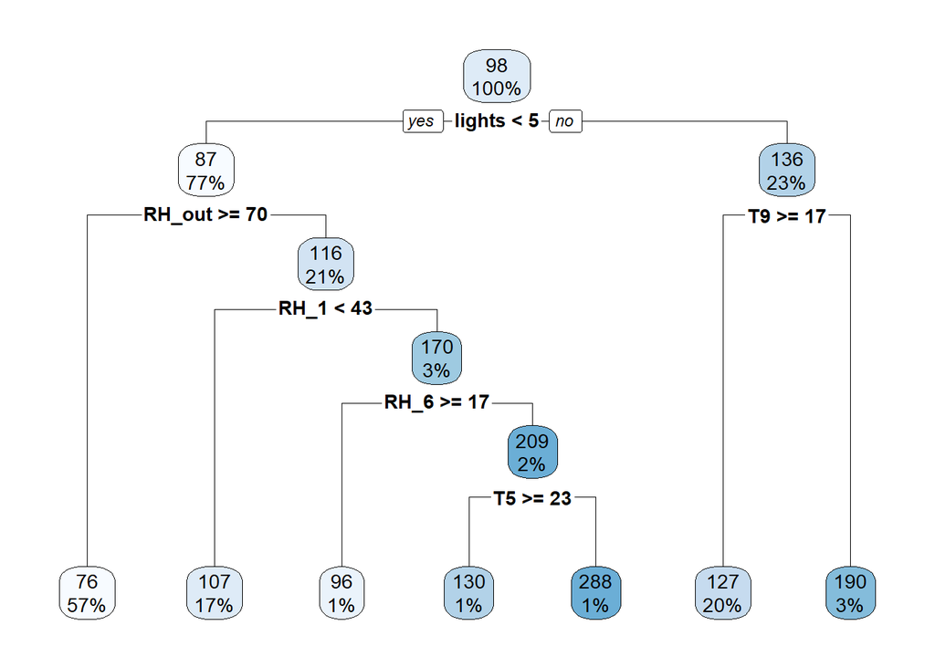

```r
#plot(model7)
library(rpart.plot)
rpart.plot(model7)
```

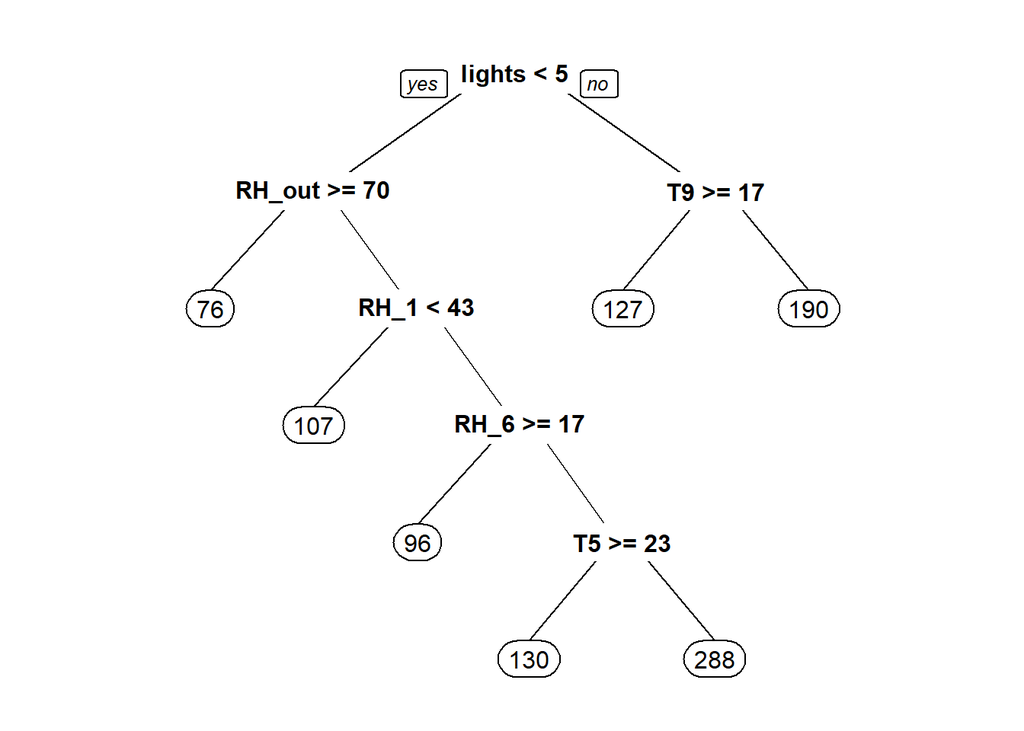

```r
prp(model7)
```

**5.** On regarde les valeurs avec un summary() ainsi qu’un cp().

```r
summary(model7)
```

```
## Call:
## rpart(formula = Appliances ~ ., data = train)
##   n= 14801
##
##           CP nsplit rel error    xerror       xstd
## 1 0.03884184      0 1.0000000 1.0001842 0.03273514
## 2 0.02258235      1 0.9611582 0.9615151 0.03155883
## 3 0.01039579      2 0.9385758 0.9394116 0.03097857
## 4 0.01004078      3 0.9281800 0.9313350 0.03050592
## 5 0.01000000      6 0.8980577 0.9280325 0.03048592
##
## Variable importance
## lights     T9 RH_out     T5     T7   RH_6   RH_7     T1     T6   RH_1   RH_8
##     15     10      9      8      8      8      5      5      4      4      4
##     T3     T4   RH_2   RH_3   RH_4   RH_9     T8  T_out
##      3      3      3      3      3      2      2      2
##
## Node number 1: 14801 observations,    complexity param=0.03884184
##   mean=98.00284, MSE=10702.77
##   left son=2 (11429 obs) right son=3 (3372 obs)
##   Primary splits:
##       lights    < 5        to the left,  improve=0.03884184, (0 missing)
##       RH_out    < 80.72222 to the right, improve=0.02264698, (0 missing)
##       T2        < 19.2525  to the left,  improve=0.01784253, (0 missing)
##       RH_6      < 16.77833 to the right, improve=0.01541066, (0 missing)
##       Windspeed < 3.154762 to the left,  improve=0.01259686, (0 missing)
##   Surrogate splits:
##       RH_3 < 46.21867 to the left,  agree=0.778, adj=0.026, (0 split)
##       RH_7 < 48.35333 to the left,  agree=0.777, adj=0.020, (0 split)
##       RH_4 < 48.42455 to the left,  agree=0.775, adj=0.014, (0 split)
##       RH_9 < 51.48571 to the left,  agree=0.775, adj=0.010, (0 split)
##       T4   < 15.28167 to the right, agree=0.774, adj=0.009, (0 split)
##
## Node number 2: 11429 observations,    complexity param=0.02258235
##   mean=86.92799, MSE=8274.008
##   left son=4 (8393 obs) right son=5 (3036 obs)
##   Primary splits:
##       RH_out < 70.41667 to the right, improve=0.03782965, (0 missing)
##       RH_6   < 16.77833 to the right, improve=0.03172572, (0 missing)
##       T6     < 10.42071 to the left,  improve=0.02383888, (0 missing)
```

[output cut: 78 more lines]

```
##       RH_7      < 37.95233 to the right, improve=0.1410893, (0 missing)
##       RH_5      < 50.99926 to the right, improve=0.1360864, (0 missing)
##       T9        < 23.07571 to the right, improve=0.1325236, (0 missing)
##   Surrogate splits:
##       T9   < 23.06143 to the right, agree=0.914, adj=0.827, (0 split)
##       T1   < 24.40833 to the right, agree=0.900, adj=0.800, (0 split)
##       T7   < 23.89673 to the right, agree=0.880, adj=0.760, (0 split)
##       T4   < 24.61667 to the right, agree=0.850, adj=0.700, (0 split)
##       RH_7 < 38.79333 to the right, agree=0.827, adj=0.653, (0 split)
##
## Node number 46: 150 observations
##   mean=129.8667, MSE=11269.32
##
## Node number 47: 151 observations
##   mean=287.8808, MSE=43064.38
```

```r
printcp(model7)
```

```
##
## Regression tree:
## rpart(formula = Appliances ~ ., data = train)
##
## Variables actually used in tree construction:
## [1] lights RH_1   RH_6   RH_out T5     T9
##
## Root node error: 158411764/14801 = 10703
##
## n= 14801
##
##         CP nsplit rel error  xerror     xstd
## 1 0.038842      0   1.00000 1.00018 0.032735
## 2 0.022582      1   0.96116 0.96152 0.031559
## 3 0.010396      2   0.93858 0.93941 0.030979
## 4 0.010041      3   0.92818 0.93134 0.030506
## 5 0.010000      6   0.89806 0.92803 0.030486
```

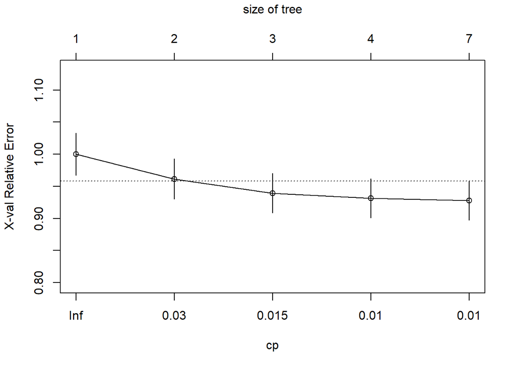

```r
plotcp(model7)
```

**6.** On calcule le RMSE.

```r
rmse_calculator <- function (actual, predicted)
{
    sqrt(mean((actual-predicted)^2))
}

prediction7 <- predict(model7, test_data)
rmse_calculator(prediction7, test_data[,"Appliances"])
```

```
## [1] 102.5206
```

**7.** On crée un modèle avec randomForest.

```r
model8=randomForest(Appliances~.,data=train,mtry=1,importance=TRUE,ntrees=5)
model8
```

```
##
## Call:
##  randomForest(formula = Appliances ~ ., data = train, mtry = 1,      importance = TRUE, ntrees = 5)
##                Type of random forest: regression
##                      Number of trees: 500
## No. of variables tried at each split: 1
##
##           Mean of squared residuals: 5491.237
##                     % Var explained: 48.69
```

```r
prediction8=predict(model8,newdata=test_data)
rmse_calculator(prediction8, test_data[,"Appliances"])
```

```
## [1] 44.44732
```

**8.** on utilise la fonction importance() pour voir les prédicteurs les plus importants dans le modèle.

```r
importance(model8,type=1)
```

```
##               %IncMSE
## lights      27.711076
## T1          23.727058
## RH_1        26.146894
## T2          29.977498
## RH_2        24.514950
## T3          24.161458
## RH_3        29.515473
## T4          26.320774
## RH_4        26.584498
## T5          27.918358
## RH_5        32.738655
## T6          24.329335
## RH_6        24.364257
## T7          22.636510
## RH_7        26.399494
## T8          31.812484
## RH_8        25.929724
## T9          22.528803
## RH_9        29.893641
## T_out       28.714308
## Press_mm_hg 29.964556
## RH_out      21.310616
## Windspeed   28.024878
## Visibility  31.782559
## Tdewpoint   26.405325
## rv1          7.458150
## rv2          7.462763
## Day_of_week 26.752481
```

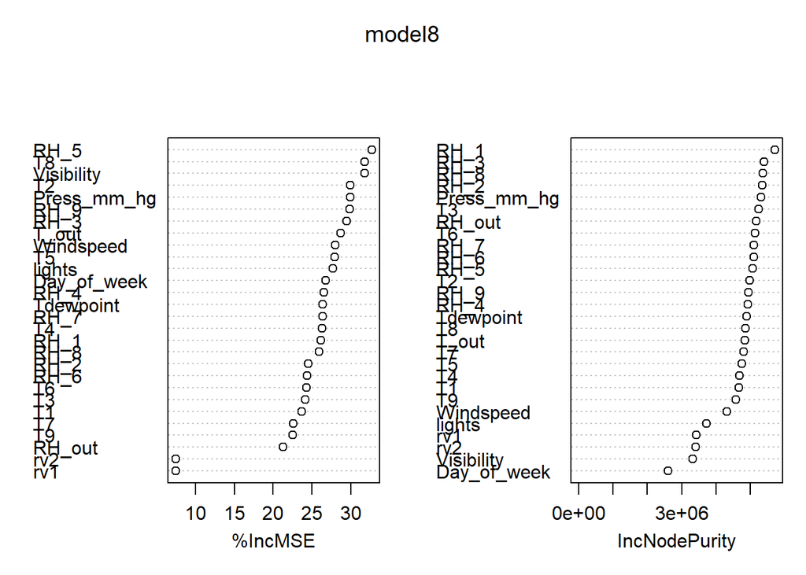

```r
varImpPlot(model8)
```

**9.** On évalue le modèle en enlevant les variables indésirées.

```r
model9=randomForest(Appliances~.-rv1-rv2,data=train,mtry=6,importance=TRUE,ntrees=500)
model9
```

```
##
## Call:
##  randomForest(formula = Appliances ~ . - rv1 - rv2, data = train,      mtry = 6, importance = TRUE, ntrees = 500)
##                Type of random forest: regression
##                      Number of trees: 500
## No. of variables tried at each split: 6
##
##           Mean of squared residuals: 4819.693
##                     % Var explained: 54.97
```

```r
prediction9=predict(model9,newdata=test_data)
rmse_calculator(prediction9, test_data[,"Appliances"])
```

```
## [1] 33.94924
```

**10.** On affine le modèle jusqu’à obtenir le meilleur score sur kaggle. Modèle final :

```r
model10=randomForest(Appliances~.-lights-Press_mm_hg-RH_1-RH_8-RH_5-T3,data=train,mtry=4,importance=TRUE,ntrees=500)

prediction10 <- predict(model10, test)

to_be_submitted = data.frame(id=rownames(test), Appliances=prediction10)
write.csv(to_be_submitted , file = "to_be_submitted.csv", row.names = F)
#to_be_submitted

# Ce n'est pas le modèle final exact sur kaggle car nous l'avons changé plusieurs fois avant de nous rendre compte que c'était le meilleur au final, mais ce model s'en rapproche beaucoup.
```